# COP26 at Fram November 2021

Analysis of the survey responses

Ben Anderson (dataknut@icloud.com)

Last run at: 2021-12-01 16:36:32

# 1 Introduction

The [Sustainability Framlingham](https://github.com/SusFram) group ran a survey in November 2021 intended to collect Framlingham residents’ views on a range of potential sustainability actions or initiatives.

The survey was distributed in two ways:

- online (available during the whole of November 2021)
- on paper at a market stall on the 6th November, timed to coincide with COP26

The online survey was communicated via various social media and the Town Council’s website/newsletter.

The market survey was available to all visitors to the stall on the 6th November and was also taken round to market visitors on that morning by students from [Framlingham College](https://www.framlinghamcollege.co.uk/). The market stall also offered information in the form of:

- posters summarising evidence on climate change as well as national and local district/parish emissions footprints;
- a leaflet on the Framlingham sustainability themes

The survey responses therefore represent the views of those who chose to respond online or who agreed to respond at the market. In both cases respondents are likely to be those who are *already* more engaged with sustainability issues and so should not be considered as representative of the views of all Framlingham residents. It is also likely that at least some responses came from non-Framlingham residents.

# 2 Data

```r
# two sources, questions asked slightly differently :-(
onlineDT_wide <- data.table::fread(paste0(dataPath, "COP26@FRAMLINGHAM SURVEY.csv"))

onlineDT <- melt(onlineDT_wide[`Do you have any comments or further ideas we can consider?` != "answers from Ben - for test purposes!"], # remove
                 id.vars = "Timestamp")

onlineDT[, question := ifelse(variable %like% "improve energy efficiency",
                              "1",
                              NA)]
onlineDT[, question := ifelse(variable %like% "electric vehicle",
                              "2",
                              question)]
onlineDT[, question := ifelse(variable %like% "renewable electricity",
                              "3",
                              question)]
onlineDT[, question := ifelse(variable %like% "Reducing car journeys",
                              "4",
                              question)]
onlineDT[, question := ifelse(variable %like% "solar panel",
                              "5",
                              question)]
onlineDT[, question := ifelse(variable %like% "thermal imaging camera",
                              "6",
                              question)]
onlineDT[, question := ifelse(variable %like% "make space for nature",
                              "7",
                              question)]
onlineDT[, question := ifelse(variable %like% "wildlife corridors",
                              "8",
                              question)]
onlineDT[, question := ifelse(variable %like% "green space management",
                              "9",
                              question)]
onlineDT[, question := ifelse(variable %like% "native planting",
                              "10",
                              question)]
onlineDT[, question := ifelse(variable %like% "bigger recycling centre",
                              "11",
                              question)]
onlineDT[, question := ifelse(variable %like% "swap and mend",
                              "12",
                              question)]
onlineDT[, question := ifelse(variable %like% "single use plastic",
                              "13",
                              question)]
onlineDT[, question := ifelse(variable %like% "compostable bags",
                              "14",
                              question)]
onlineDT[, question := ifelse(variable %like% "rainwater",
                              "15",
                              question)]
onlineDT[, question := ifelse(variable %like% "flood plains",
                              "16",
                              question)]
onlineDT[, question := ifelse(variable %like% "summer shading",
                              "17",
                              question)]
onlineDT[, question := ifelse(variable %like% "overheating",
                              "18",
                              question)]
onlineDT[, question := ifelse(variable %like% "comments",
                              "comments",
                              question)]
onlineDT[, response_str := value]
onlineDT[, source := "On-line"]

paperDF <- readxl::read_xlsx(paste0(dataPath, "COP26@FramMarket-Survey-Data.xlsx"), sheet = "paper")

paperDT <- data.table::as.data.table(paperDF)

# code paper response for easier comparison
paperDT[, response_str := ifelse(response >= 1,
                                 "Yes (1+ ticks)",
                                 response)]
paperDT[, response_str := ifelse(is.na(response_str),
                                 "No (empty)",
                                 response_str)]
paperDT[, response_str := ifelse(response_str == -1,
                                 "No (cross)",
                                 response_str)]
paperDT[, response_str := ifelse(response_str == -99,
                                 "Don't know (stated)",
                                 response_str)]
# now code the final comments box
paperDT[, response_str := ifelse(question == "comments",
                                 comment,
                                 response_str)]
paperDT[, source := "Paper"]
# select the variables that match and rbind them into one data file

dataDT <- rbind(paperDT[, .(survey_id, question, response_str, source)],
      onlineDT[, .(survey_id = Timestamp, question, response_str, source)])
```

There were 118 survey responses. Of these:

- 58 were on-line responses between 2021-10-19 and 2021-11-17;
- 60 were paper-based responses collected at the market on 2021-11-06.

Table 2.1 shows the survey questions. These were worded identically in the online and paper-based surveys.

```r
t <- unique(onlineDT[, .(variable)])
makeFlexTable(t, cap = "Survey questions")
```

Table 2.1: Survey questions

| variable |
| --- |
| 1 DO YOU SUPPORT: Initiatives to improve energy efficiency (e.g. insulation, double glazing) including listed buildings? |
| 2 DO YOU SUPPORT: Installing publicly accessible electric vehicle charging points? |
| 3 DO YOU SUPPORT: Encouraging homes and businesses to switch to renewable electricity suppliers? |
| 4 DO YOU SUPPORT: Reducing car journeys - encourage local shopping, walk to school and car sharing schemes? |
| 5 DO YOU SUPPORT: Promoting community solar panel and heat pump purchase schemes? |
| 6 DO YOU SUPPORT: Providing a thermal imaging camera free for residents to borrow to identify heat loss from homes? |
| 7 DO YOU SUPPORT: Calling for new buildings to ‘make space for nature’ by designing for natural plant and wildlife habitats? |
| 8 DO YOU SUPPORT: Working to create linked green wildlife corridors through and around the town? |
| 9 DO YOU SUPPORT: Ensuring that green space management boosts local wildlife and encourage local land owners to do the same? |
| 10 DO YOU SUPPORT: Allocating land to native planting, wildlife habitats and 're-wilding' via the Neighbourhood Plan |
| 11 DO YOU SUPPORT: Having a bigger recycling centre on the edge of Framlingham for a wider range of materials? |
| 12 DO YOU SUPPORT: Encouraging swap and mend initiatives? |
| 13 DO YOU SUPPORT: Aiming to get rid of all single use plastic (starting with bags & take away packaging)? |
| 14 DO YOU SUPPORT: Aiming to supply compostable bags at cost price, or free at point of use? |
| 15 DO YOU SUPPORT: Calling for new buildings and renovations to be designed to reduce or store rainwater run-off? |
| 16 DO YOU SUPPORT: Working to prevent unsustainable development on local flood plains? |
| 17 DO YOU SUPPORT: Encouraging native tree planting to provide summer shading throughout the town? |
| 18 DO YOU SUPPORT: Exploring options for reducing the risk of overheating in buildings? |
| Do you have any comments or further ideas we can consider? |

However the potential responses for the paper-based and online surveys differed:

- online: options were yes, no, maybe and there was only the opportunity to add comments at the end in a specific ‘further ideas or comments’ question;
- paper: respondents were asked to tick boxes next to the options they would support - we have therefore coded empty tick boxes as ‘no’ but also coded boxes which were marked with an X as a more intentional ‘No.’ A number of paper respondents added comments beside their responses to each question. These are reported below each plot as a table - where the table is empty there were no specific comments.

In order to avoid confusion and maintain transparency the responses from the two forms of the survey are presented separately (but on the same plots) below.

# 3 Results

## 3.1 Emissions reduction

### 3.1.1 Q1: Initiatives to improve energy efficiency (e.g. insulation, double glazing) including listed buildings?

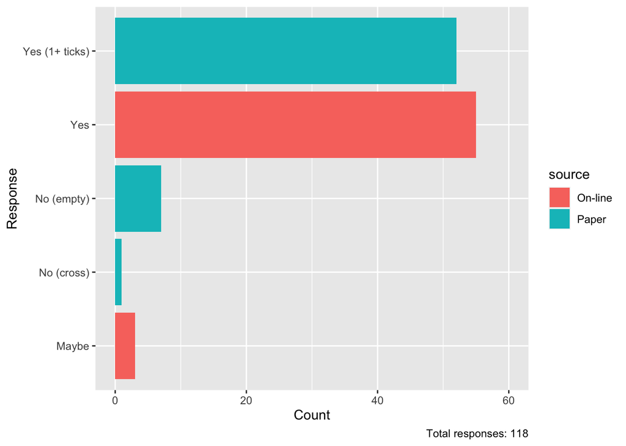

```r
q <- "1"

makeBarPlot(dataDT, q)
```

```r
t <- paperDT[question == q & !is.na(comment), .(comment)]

makeFlexTable(t, cap = "Specific comments for this question (paper survey only)")
```

Table 3.1: Specific comments for this question (paper survey only)

| comment |
| --- |
| assisting in applications for grants for insulation & effective home heating for elderly & vulnerable |
| Obliging all developers to build new buildings with sustainable materials & properly insulated with carbon neutral heating systems, Developers comply with requirements of the council & not alter the p… |

### 3.1.2 Q2: Installing publicly accessible electric vehicle charging points

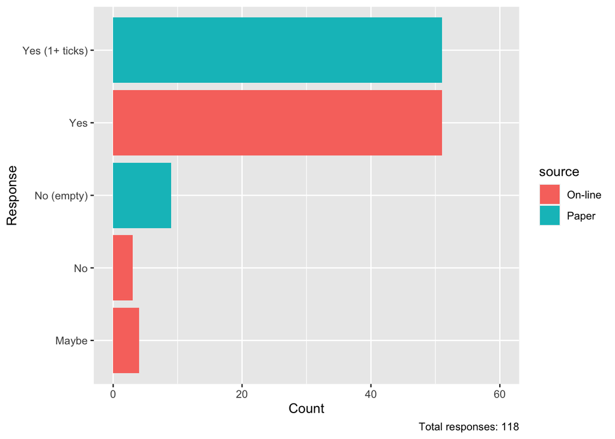

```r
q <- "2"

makeBarPlot(dataDT, q)
```

```r
t <- paperDT[question == q & !is.na(comment), .(comment)]

makeFlexTable(t, cap = "Specific comments for this question (paper survey only)")
```

Table 3.2: Specific comments for this question (paper survey only)

| comment |
| --- |

### 3.1.3 Q3: Encouraging homes and businesses to switch to renewable electricity suppliers

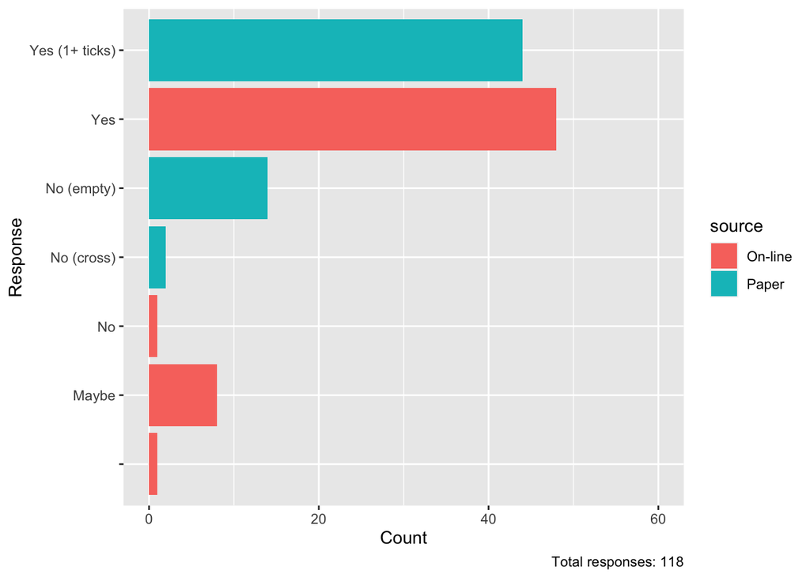

```r
q <- "3"

makeBarPlot(dataDT, q)
```

```r
t <- paperDT[question == q & !is.na(comment), .(comment)]

makeFlexTable(t, cap = "Specific comments for this question (paper survey only)")
```

Table 3.3: Specific comments for this question (paper survey only)

| comment |
| --- |

### 3.1.4 Q4: Reducing car journeys - encourage local shopping, walk to school and car sharing schemes

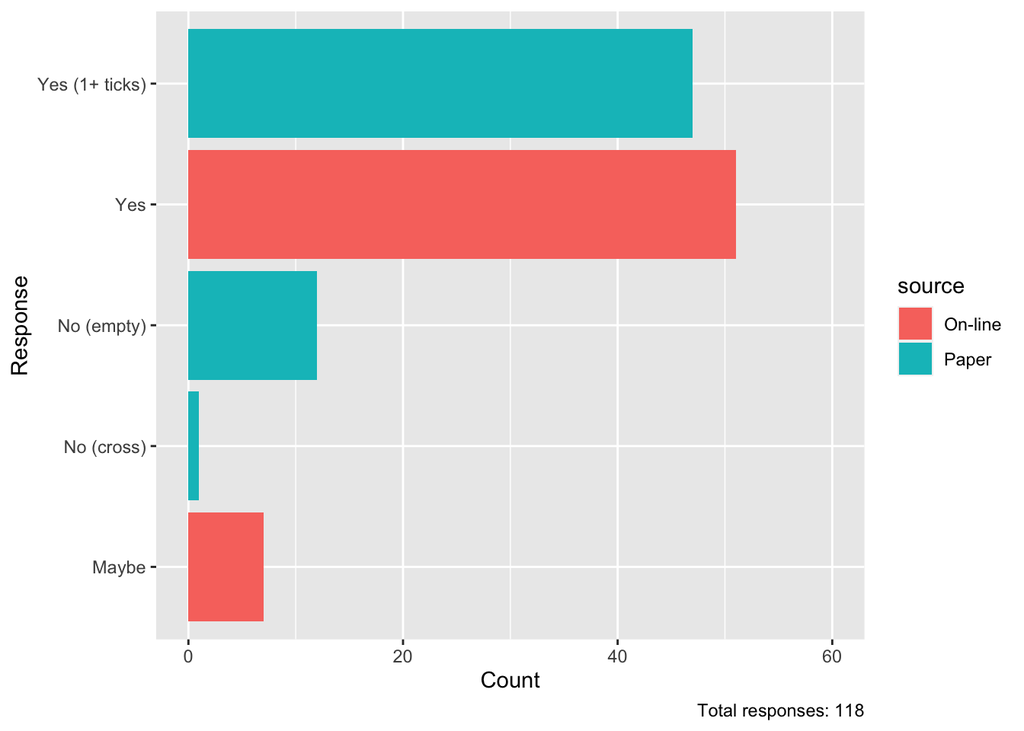

```r
q <- "4"

makeBarPlot(dataDT, q)
```

```r
t <- paperDT[question == q & !is.na(comment), .(comment)]

makeFlexTable(t, cap = "Specific comments for this question (paper survey only)")
```

Table 3.4: Specific comments for this question (paper survey only)

| comment |
| --- |
| Bring back bus to rural villages |
| Minimise car travel, provide pedestrian/cycle use, Zebra crossing near Fram DIY to promotoe walking, |
| Close off Fram market to cars to encourage walking; introduce e-scooter schemes to reduce car use into town |
| Better & more bike racks - especially for cargo bikes + longer tandems / pulling trailers |
| car sharing schemes? |
| More public services leaving & returning to Framlingham |
| This! |

### 3.1.5 Q5: Promoting community solar panel and heat pump purchase schemes

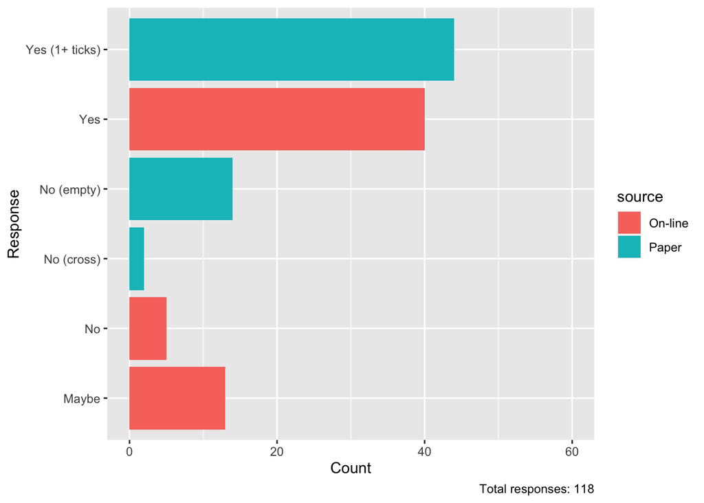

```r
q <- "5"

makeBarPlot(dataDT, q)
```

```r
t <- paperDT[question == q & !is.na(comment), .(comment)]

makeFlexTable(t, cap = "Specific comments for this question (paper survey only)")
```

Table 3.5: Specific comments for this question (paper survey only)

| comment |
| --- |
| cost? |
| Subsidy or grants |

### 3.1.6 Q6: Providing a thermal imaging camera free for residents to borrow to identify heat loss from homes

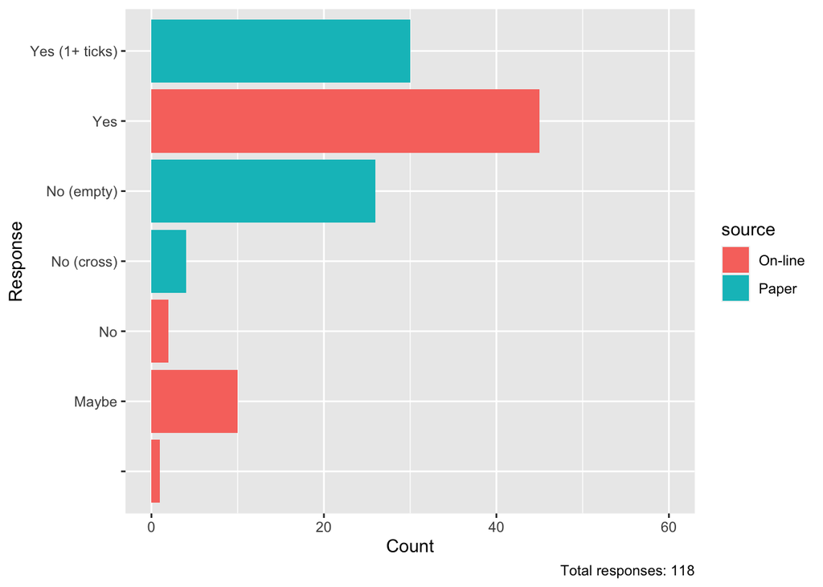

```r
q <- "6"

makeBarPlot(dataDT, q)
```

```r
t <- paperDT[question == q & !is.na(comment), .(comment)]

makeFlexTable(t, cap = "Specific comments for this question (paper survey only)")
```

Table 3.6: Specific comments for this question (paper survey only)

| comment |
| --- |
| Good but costly |

## 3.2 Biodiversity enhacement

### 3.2.1 Q7: Calling for new buildings to ‘make space for nature’ by designing for natural plant and wildlife habitats

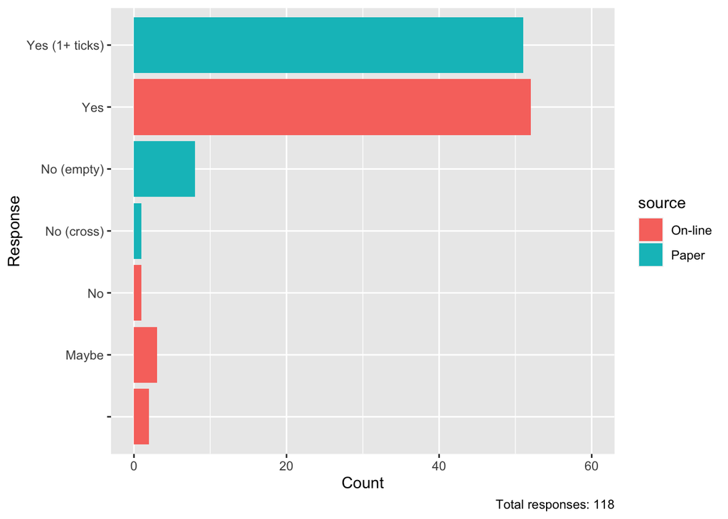

```r
q <- "7"

makeBarPlot(dataDT, q)
```

```r
t <- paperDT[question == q & !is.na(comment), .(comment)]

makeFlexTable(t, cap = "Specific comments for this question (paper survey only)")
```

Table 3.7: Specific comments for this question (paper survey only)

| comment |
| --- |
| As long as housing doesn’t sprawl |

### 3.2.2 Q8: Working to create linked green wildlife corridors through and around the town

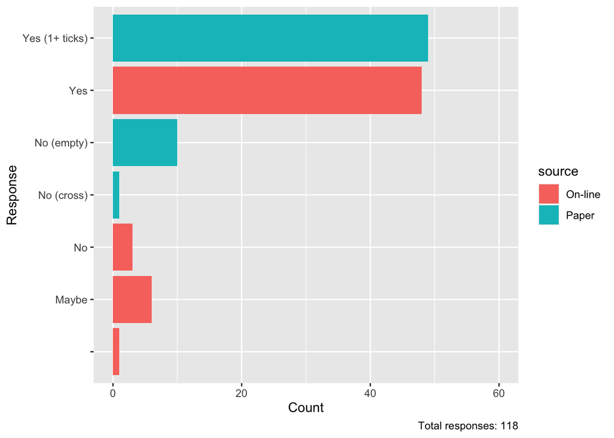

```r
q <- "8"

makeBarPlot(dataDT, q)
```

```r
t <- paperDT[question == q & !is.na(comment), .(comment)]

makeFlexTable(t, cap = "Specific comments for this question (paper survey only)")
```

Table 3.8: Specific comments for this question (paper survey only)

| comment |
| --- |
| encourage locals to adopt lanes & verges to prevent spring cutting |

### 3.2.3 Q9: Ensuring that green space management boosts local wildlife and encourage local land owners to do the same

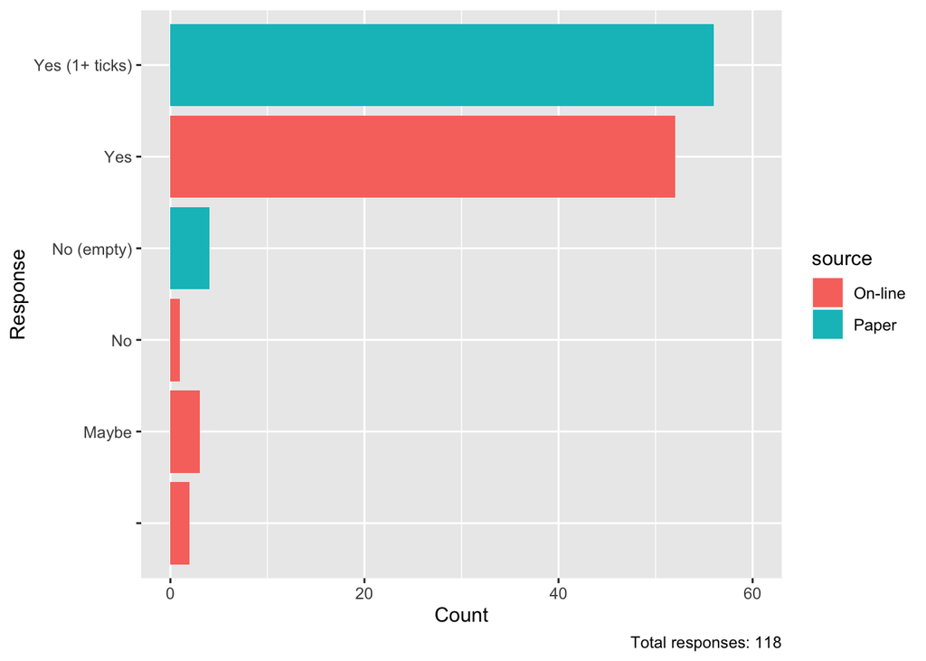

```r
q <- "9"

makeBarPlot(dataDT, q)
```

```r
t <- paperDT[question == q & !is.na(comment), .(comment)]

makeFlexTable(t, cap = "Specific comments for this question (paper survey only)")
```

Table 3.9: Specific comments for this question (paper survey only)

| comment |
| --- |
| Already done? |
| Encourage re-wilding pledges to home & business premises |

### 3.2.4 Q10: Allocating land to native planting, wildlife habitats and ‘re-wilding’ via the Neighbourhood Plan

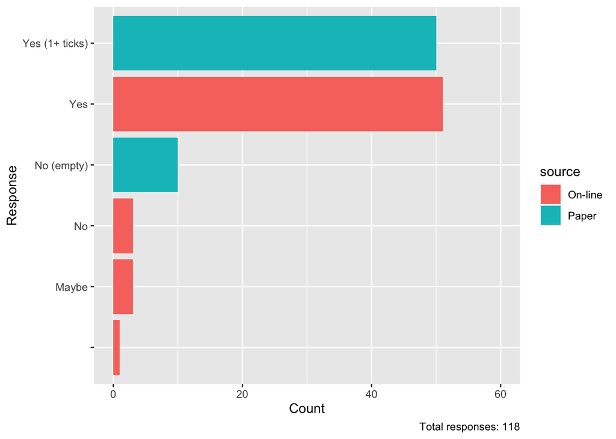

```r
q <- "10"

makeBarPlot(dataDT, q)
```

```r
t <- paperDT[question == q & !is.na(comment), .(comment)]

makeFlexTable(t, cap = "Specific comments for this question (paper survey only)")
```

Table 3.10: Specific comments for this question (paper survey only)

| comment |
| --- |
| As long as managed cost? |
| rewilding gardening practices |

## 3.3 Least Trace Living

### 3.3.1 Q11: Having a bigger recycling centre on the edge of Framlingham for a wider range of materials

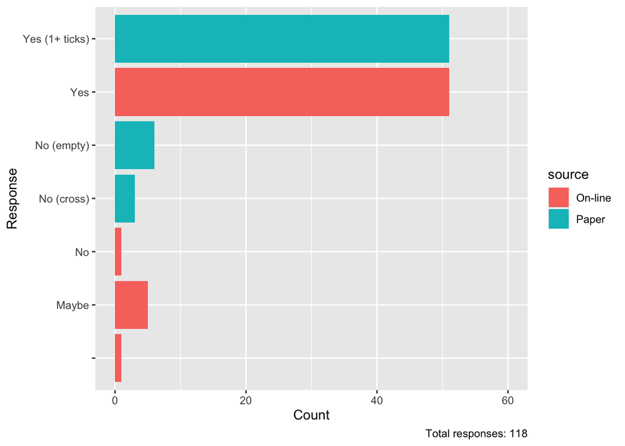

```r
q <- "11"

makeBarPlot(dataDT, q)
```

```r
t <- paperDT[question == q & !is.na(comment), .(comment)]

makeFlexTable(t, cap = "Specific comments for this question (paper survey only)")
```

Table 3.11: Specific comments for this question (paper survey only)

| comment |
| --- |
| No |
| We need easier ways to recycle items locally |
| Parking problem, who has priority? |

### 3.3.2 Q12: Encouraging swap and mend initiatives

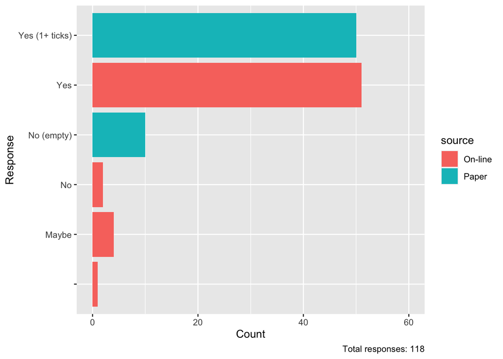

```r
q <- "12"

makeBarPlot(dataDT, q)
```

```r
t <- paperDT[question == q & !is.na(comment), .(comment)]

makeFlexTable(t, cap = "Specific comments for this question (paper survey only)")
```

Table 3.12: Specific comments for this question (paper survey only)

| comment |
| --- |
| At variety of times so access to all |
| Educating on mending, charity shop fashion show |
| Thru social network (Fram fb) or pick-up point |
| including exchange of unwanted/2nd hand clothes - maybe a stand in the market? |

### 3.3.3 Q13: Aiming to get rid of all single use plastic (starting with bags & take away packaging)

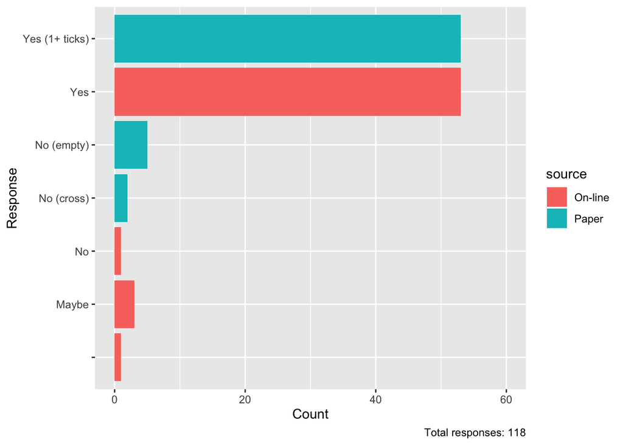

```r
q <- "13"

makeBarPlot(dataDT, q)
```

```r
t <- paperDT[question == q & !is.na(comment), .(comment)]

makeFlexTable(t, cap = "Specific comments for this question (paper survey only)")
```

Table 3.13: Specific comments for this question (paper survey only)

| comment |
| --- |
| Bigger bin at co-op |
| 100% ban, supermarkets, small businesses; lobby supermarket to stop all supply of plastic bags & reduce plastic packaging |

### 3.3.4 Q14: Aiming to supply compostable bags at cost price, or free at point of use

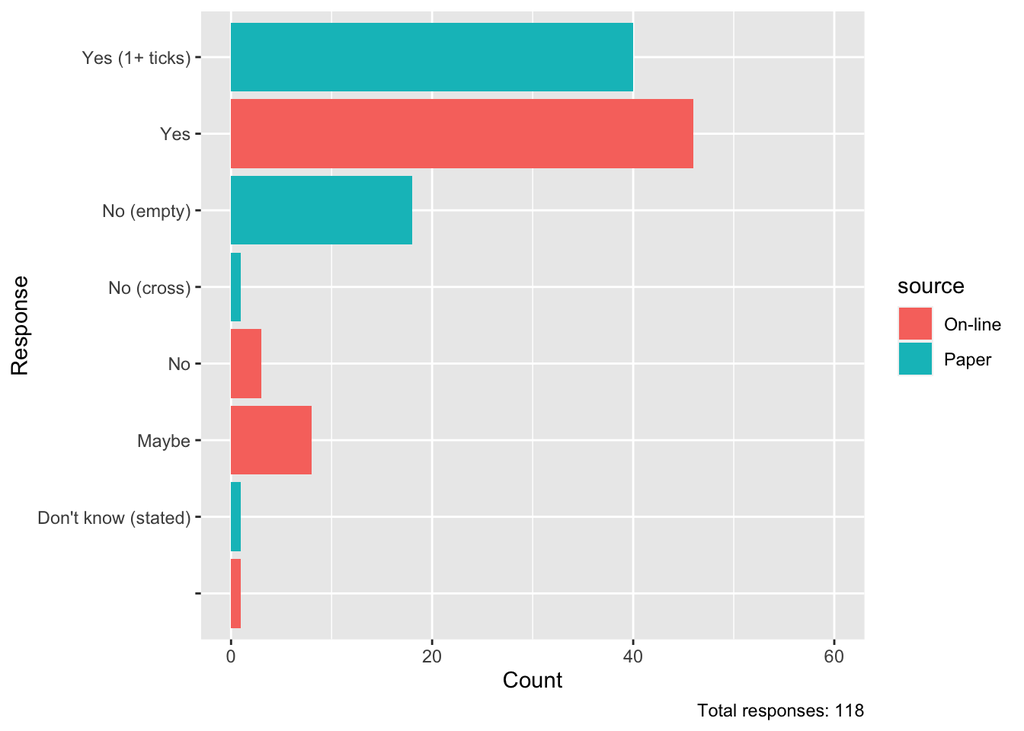

```r
q <- "14"

makeBarPlot(dataDT, q)
```

```r
t <- paperDT[question == q & !is.na(comment), .(comment)]

makeFlexTable(t, cap = "Specific comments for this question (paper survey only)")
```

Table 3.14: Specific comments for this question (paper survey only)

| comment |
| --- |
| Just ban plastic bags 100% |
| ? |

## 3.4 Resilience

### 3.4.1 Q15: Calling for new buildings and renovations to be designed to reduce or store rainwater run-off

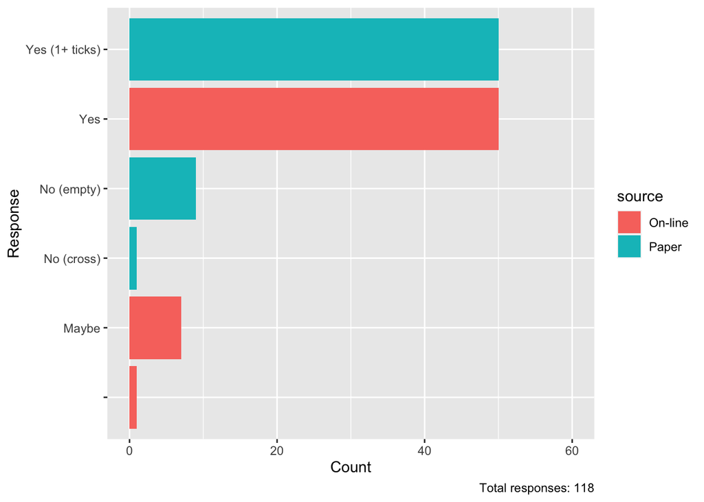

```r
q <- "15"

makeBarPlot(dataDT, q)
```

```r
t <- paperDT[question == q & !is.na(comment), .(comment)]

makeFlexTable(t, cap = "Specific comments for this question (paper survey only)")
```

Table 3.15: Specific comments for this question (paper survey only)

| comment |
| --- |
| Increase brown water use |
| All to have car charge points and renewable energy built in |

### 3.4.2 Q16: Working to prevent unsustainable development on local flood plains

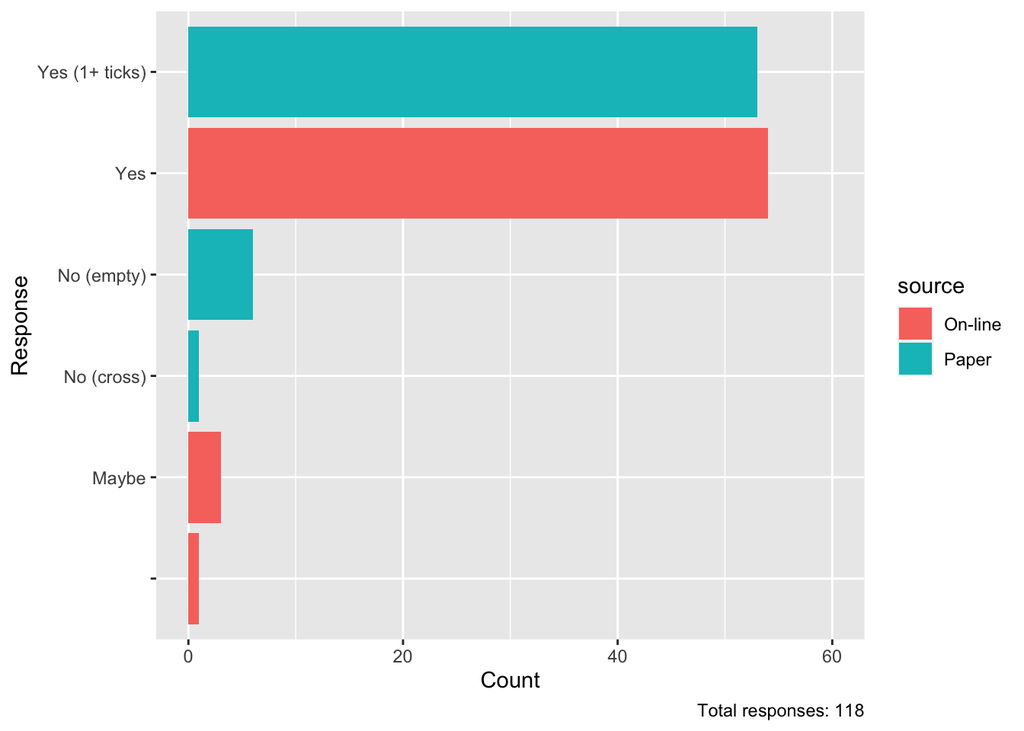

```r
q <- "16"

makeBarPlot(dataDT, q)
```

```r
t <- paperDT[question == q & !is.na(comment), .(comment)]

makeFlexTable(t, cap = "Specific comments for this question (paper survey only)")
```

Table 3.16: Specific comments for this question (paper survey only)

| comment |
| --- |
| Again good idea, but costly |

### 3.4.3 Q17: Encouraging native tree planting to provide summer shading throughout the town

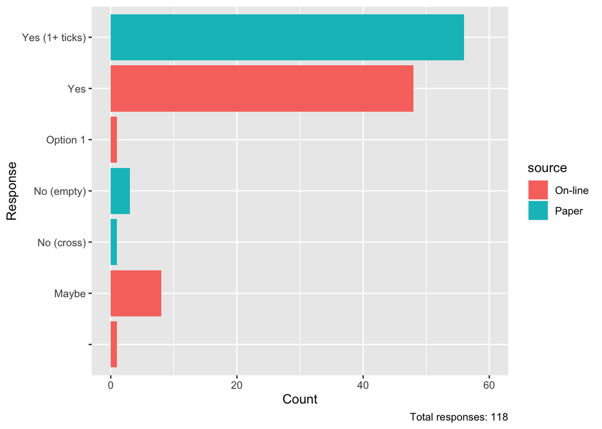

```r
q <- "17"

makeBarPlot(dataDT, q)
```

```r
t <- paperDT[question == q & !is.na(comment), .(comment)]

makeFlexTable(t, cap = "Specific comments for this question (paper survey only)")
```

Table 3.17: Specific comments for this question (paper survey only)

| comment |
| --- |

### 3.4.4 Q18: Exploring options for reducing the risk of overheating in buildings

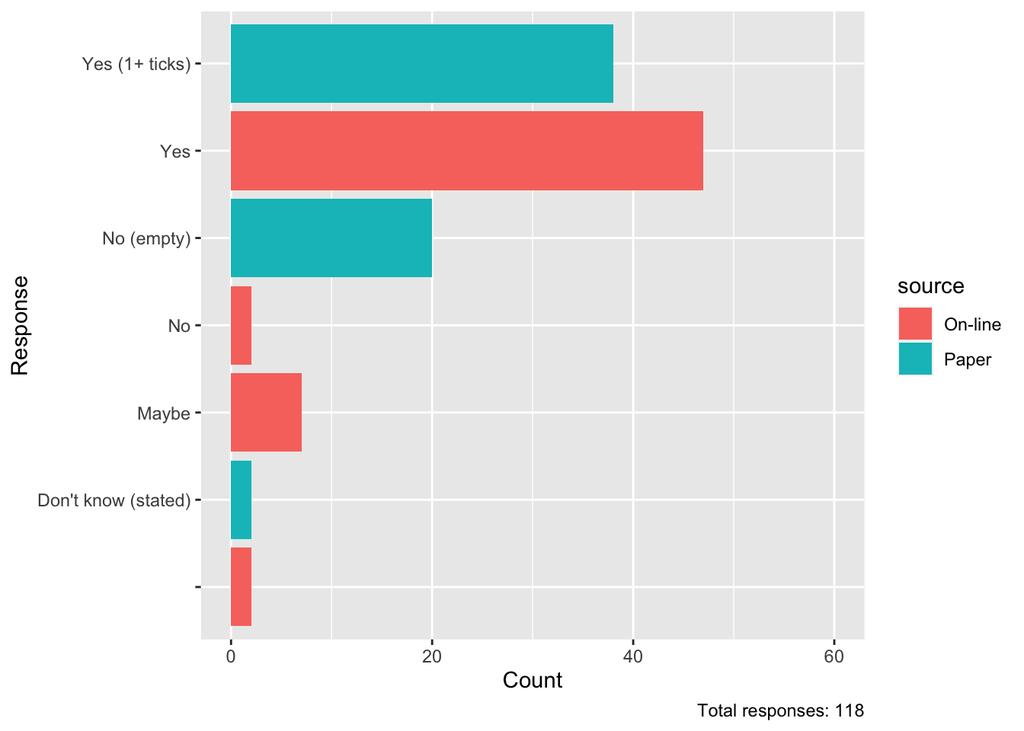

```r
q <- "18"

makeBarPlot(dataDT, q)
```

```r
t <- paperDT[question == q & !is.na(comment), .(comment)]

makeFlexTable(t, cap = "Specific comments for this question (paper survey only)")
```

Table 3.18: Specific comments for this question (paper survey only)

| comment |
| --- |
| dk ? |
| ? |

## 3.5 General comments

The table below shows all general comments made at the end of the survey. No attempt has yet been made to cluster these by theme.

Please flag any that you consider disclosive (i.e. could identify the respondent) and these will be redacted in some way!

```r
q <- "comments"

t <- dataDT[question == q & !is.na(response_str) &
              response_str != "", .(Comment = response_str, source)]

# remove anything that looks like an email address
pattern <- "[a-z]*@[a-z]*[.][a-z]*"
t[, Comment := stringr::str_replace(Comment, pattern, " <XX email redacted XX> ")]

makeFlexTable(t, cap = "General comments for this question (both surveys)")
```

Table 3.19: General comments for this question (both surveys)

| Comment | source |
| --- | --- |
| Encourage rubbish clearing!! Schools should encourage children, co-op should be encouraged to get rid of plastic around veg/fruit etc | Paper |
| Dog bags (compostable) | Paper |
| Bottle bank near high school, repairs shop | Paper |
| Community garden, orchard, allotment, park & ride | Paper |
| Terra recycling in Fram | Paper |
| Community composting initiative, School projects to educate the young, engage local youth groups, | Paper |
| Invest in brown field sites, help offset costs for solar/wind etc (indecipherable) | Paper |
| Loads of ideas here, needs prioritising | Paper |
| Educate households on food composting, reduced food waste, encourage supermarkets to source local & reduce carbon footprints | Paper |
| Community orchard & space for outdoor learning; free (if possible) vegetarian/vegan cooking demonstrations | Paper |
| Safe cycling routes | Paper |
| All very good & worthwhile, can't come soon enough | Paper |
| Refill stations | Paper |
| Try to build the younger population so the age gap can be straightened | Paper |
| Use sheep wool for insulation | Paper |
| I would like to see a hedgerow initiative. When I walk around town I see a lots of perimeters that could be occupied by a nice hedgerow. | On-line |
| How can Fram capture excess rainwater? | On-line |
| If we are all going to have electric cars, where are the electric supply points going to be? I have no driveway and have to park on the road in the middle of Framlingham, often at some distance to my … | On-line |
| New buildings should have swift bricks in them this was a major mistake with all the new houses in terms if wildlife no provisions were made. Many new owners on the Taylor wimpey site have paid to hav… | On-line |
| Getting rid of single use plastic will likely mean more paper bags. The committee should understand the hugely negative impact this also has on the environment as it is constantly being overlooked wit… | On-line |
| Reduce the cost of green bins to help stop fly tipping. | On-line |
| Turn off street lighting (or at leat reduce the light polution levels) from 0001hrs. | On-line |
| Single use plastics seems to me one of the biggest problems and ones we could most easily tackle as a community. It would be great to to get all local shops ( large or small) to stop selling products … | On-line |
| Planting schemes etc are all well and good but it’s the upkeep and ongoing maintenance which are the hard part! | On-line |
| I lived in Germany for a while and there most roads have a cycle path next to them, as a consequence we cycled everywhere as a family. Now back in suffolk living on a country road, we are acutely awar… | On-line |
| I support any strategy that promotes cycling and using bikes for ‘last mile’ delivery | On-line |
| Pedestrianise market hill during the day. Cycle paths More pedestrian crossings An outdoor clothing/ sports shop | On-line |
| New home in the area continue to be built without adequate insulation to conserve energy, no solar panels, no heat pumps etc. Developers need to be compelled to build new homes to be as energy efficie… | On-line |
| Re wilding areas to be managed and not just left wild | On-line |
| Limit development we have too much building in and around the town | On-line |
| Encourage grow your own initiatives to reduce transportation of some foods. Encourage forums to educate people about responsible actions such as reducing food waste. | On-line |
| Encouraging plant-based diets. New cycle routes and paths. A Walking Bus for primary school children (to reduce traffic in the town). Organising a regular Eco Market in the town, so that people can be… | On-line |
| I feel that any new housing developments should be eco friendly and built to the highest environmental standards. I would also like pressure put on the Co-op to reduce packaging or switch to compostab… | On-line |
| We would love to have local tetrapak recycling- currently we have to go to Leiston or Foxhall. More plant based options at eateries in the town to help reduce our food's carbon footprint would be grea… | On-line |
| I would need help to make some changes eg switching power companies, loft insulation etc. I buy local produce on the market but object to the Co-op being the only place to shop = they just corner the … | On-line |
| Asking supermarkets to consider building a store out of town to lift the weight of traffic away from town centre | On-line |
| We need to promote new attitudes in people in order to ring in change. People are stuck firmly in their ways and we need people to set examples to the community. I suggest rewards and celebrations on … | On-line |
| Working with retailers to encourage/entice customers to choose greener options…speaking as a retailer! | On-line |
| I’d love to help and support but this is such a poorly worded survey that I just got fed up with basically being asked if I agree with you or not. No room for other thoughts? | On-line |
| I have agreed with all the above. Need to put forward lowering carbon footprint as a positive if we are to engage with public and change to happen. | On-line |
| Well done to all involved in this and thank you. Most folk want to be ‘green’ - just sometimes need some help getting there…. Solar heating does not need panels and on a listed building or indeed anyw… | On-line |
| There are miles and miles of farmers fields locally that could very easily be re hedged with native plants - trees . It would be great if the local farmers would agree for the re hedging to be carried… | On-line |
| Excellent survey. We at Enterprise Badingham would be interested in any future initiatives. We have planted some fruit trees, run the community gardens, have a local roadside Nature Reserve, and are g… | On-line |
| Not right now, because you seem to have covered everything. Good luck! | On-line |
| Green initiatives need to be accessible for all - make them easy to use, affordable, reward people to promote good practice - look at how both big & small businesses as well as homeowners can help. | On-line |

## 3.6 Additional comments

In addition to the above the following general comments were also made.

- investigate a tree & woodland strategy - c.f. Stonehouse Town Council’s [Arboretum](https://treecare.org.uk/2243/stonehouse-community-arboretum-management-plan-launched/) - strategy prepared by Barcham (local contact)
- investigate Debenham Repairs shed - Friday afternoons
- electric car chargers - could make 2 types available (fast & standard) but consider implications of each for how long vehicle would ‘need’ to be plugged in
- old oil tank comment?
- investigate Enterprise @ Badingham

# 4 Summary

Overall the respondents to the survey were generally supportive of all actions proposed.

```r
dataDT[, yes_response := ifelse(response_str %like% "Yes",
                                "Yes", "Other")]
dataDT[, no_response := ifelse(response_str %like% "No",
                                "No", "Other")]

yesDT <- dataDT[question != "comments", .(count = .N), keyby = .(question, yes_response)]
noDT <- dataDT[question != "comments", .(count = .N), keyby = .(question, no_response)]

nResponses <- uniqueN(dataDT$survey_id)

questionText <- data.table::as.data.table(table(onlineDT$variable))
questionText$question <- as.character(1:nrow(questionText))

yesDT[, pc_yes := 100*count/nResponses]
setkey(questionText, question)
setkey(yesDT, question)
yes_t <- yesDT[questionText[question != 19, # avoid comments question
                            .(question, text = V1)]]

noDT[, pc_no := 100*count/nResponses]
setkey(questionText, question)
setkey(noDT, question)
no_t <- noDT[questionText[question != 19, .(question, text = V1)]]
```

Actions that were most strongly supported (> 80% of responses were ‘yes’) are shown in Table 4.1.

```r
t <- yes_t[yes_response == "Yes" & pc_yes > 80][order(-pc_yes)]

makeFlexTable(head(t[, .(Question = text, `% yes` = pc_yes)]), cap = "Most strongly supported")
```

Table 4.1: Most strongly supported

| Question | % yes |
| --- | --- |
| 9 DO YOU SUPPORT: Ensuring that green space management boosts local wildlife and encourage local land owners to do the same? | 91.5 |
| 1 DO YOU SUPPORT: Initiatives to improve energy efficiency (e.g. insulation, double glazing) including listed buildings? | 90.7 |
| 16 DO YOU SUPPORT: Working to prevent unsustainable development on local flood plains? | 90.7 |
| 13 DO YOU SUPPORT: Aiming to get rid of all single use plastic (starting with bags & take away packaging)? | 89.8 |
| 17 DO YOU SUPPORT: Encouraging native tree planting to provide summer shading throughout the town? | 88.1 |
| 7 DO YOU SUPPORT: Calling for new buildings to ‘make space for nature’ by designing for natural plant and wildlife habitats? | 87.3 |

Actions that were least strongly supported (> 10% of responses were ‘no’) are shown in Table 4.2.

```r
t <- no_t[no_response == "No" & pc_no > 10][order(-pc_no)]

makeFlexTable(head(t[, .(Question = text, `% no` = pc_no)]), cap = "Least strongly supported")
```

Table 4.2: Least strongly supported

| Question | % no |
| --- | --- |
| 6 DO YOU SUPPORT: Providing a thermal imaging camera free for residents to borrow to identify heat loss from homes? | 27.1 |
| 14 DO YOU SUPPORT: Aiming to supply compostable bags at cost price, or free at point of use? | 18.6 |
| 18 DO YOU SUPPORT: Exploring options for reducing the risk of overheating in buildings? | 18.6 |
| 5 DO YOU SUPPORT: Promoting community solar panel and heat pump purchase schemes? | 17.8 |
| 3 DO YOU SUPPORT: Encouraging homes and businesses to switch to renewable electricity suppliers? | 14.4 |
| 8 DO YOU SUPPORT: Working to create linked green wildlife corridors through and around the town? | 11.9 |

# 5 Annex

## 5.1 Data processing

This analysis was created using [R](https://cran.r-project.org/) embedded in [Rmarkdown](https://rmarkdown.rstudio.com/) in [RStudio](https://www.rstudio.com/).

## 5.2 R packages used

- base R (R Core Team 2016)
- bookdown (Xie 2016a)
- data.table (Dowle et al. 2015)
- ggplot2 (Wickham 2009)
- flextable (Gohel 2021)
- knitr (Xie 2016b)
- rmarkdown (Allaire et al. 2018)

# References

Allaire, JJ, Yihui Xie, Jonathan McPherson, Javier Luraschi, Kevin Ushey, Aron Atkins, Hadley Wickham, Joe Cheng, and Winston Chang. 2018. *Rmarkdown: Dynamic Documents for r*. https://CRAN.R-project.org/package=rmarkdown.

Dowle, M, A Srinivasan, T Short, S Lianoglou with contributions from R Saporta, and E Antonyan. 2015. *Data.table: Extension of Data.frame*. https://CRAN.R-project.org/package=data.table.

Gohel, David. 2021. *Flextable: Functions for Tabular Reporting*. https://CRAN.R-project.org/package=flextable.

R Core Team. 2016. *R: A Language and Environment for Statistical Computing*. Vienna, Austria: R Foundation for Statistical Computing. https://www.R-project.org/.

Wickham, Hadley. 2009. *Ggplot2: Elegant Graphics for Data Analysis*. Springer-Verlag New York. http://ggplot2.org.

Xie, Yihui. 2016a. *Bookdown: Authoring Books and Technical Documents with R Markdown*. Boca Raton, Florida: Chapman; Hall/CRC. https://github.com/rstudio/bookdown.

———. 2016b. *Knitr: A General-Purpose Package for Dynamic Report Generation in r*. https://CRAN.R-project.org/package=knitr.